# MITx: 15.071x The Analytics Edge - Regression Trees for Housing Data in Boston

### April 6, 2014

# *Introduction*

A paper was written on the relationship between house prices and clean air in the late 1970s by David Harrison of Harvard and Daniel Rubinfeld of U. of Michigan. “Hedonic Housing Prices and the Demand for Clean Air” has been citedmore than 1000 times. Data set was widely used to evaluate algorithms. In this report, we will explore the dataset with the aid of trees, compare linear regression with regression trees, discuss what the “cp” parameter means and apply cross-validation to regression trees.

# *Understanding the Data*

Each entry corresponds to a census tract, a statistical division of the area that is used by researchers to break down towns and cities. There will be multiple census tracts per Town.

### *Variables*

```
LON and LAT are the longitude and latitude of the center of the census tract.
MEDV is the median value of owner-occupied homes, in thousands of dollars.
CRIM is the per capita crime rate
ZN is related to how much of the land is zoned for large residential properties
INDUS is proportion of area used for industry
CHAS is 1 if the census tract is next to the Charles River
NOX is the concentration of nitrous oxides in the air
RM is the average number of rooms per dwelling
AGE is the proportion of owner-occupied units built before 1940
DIS is a measure of how far the tract is from centers of employment in Boston
RAD is a measure of closeness to important highways
TAX is the property tax rate per $10,000 of value
PTRATIO is the pupil-teacher ratio by town
```

# *Exploratory Data Analysis*

```r
# Read Data
boston = read.csv("boston.csv")
str(boston)
```

```
## 'data.frame':    506 obs. of  16 variables:
##  $ TOWN   : Factor w/ 92 levels "Arlington","Ashland",..: 54 77 77 46 46 46 69 69 69 69 ...
##  $ TRACT  : int  2011 2021 2022 2031 2032 2033 2041 2042 2043 2044 ...
##  $ LON    : num  -71 -71 -70.9 -70.9 -70.9 ...
##  $ LAT    : num  42.3 42.3 42.3 42.3 42.3 ...
##  $ MEDV   : num  24 21.6 34.7 33.4 36.2 28.7 22.9 22.1 16.5 18.9 ...
##  $ CRIM   : num  0.00632 0.02731 0.02729 0.03237 0.06905 ...
##  $ ZN     : num  18 0 0 0 0 0 12.5 12.5 12.5 12.5 ...
##  $ INDUS  : num  2.31 7.07 7.07 2.18 2.18 2.18 7.87 7.87 7.87 7.87 ...
##  $ CHAS   : int  0 0 0 0 0 0 0 0 0 0 ...
##  $ NOX    : num  0.538 0.469 0.469 0.458 0.458 0.458 0.524 0.524 0.524 0.524 ...
##  $ RM     : num  6.58 6.42 7.18 7 7.15 ...
##  $ AGE    : num  65.2 78.9 61.1 45.8 54.2 58.7 66.6 96.1 100 85.9 ...
##  $ DIS    : num  4.09 4.97 4.97 6.06 6.06 ...
##  $ RAD    : int  1 2 2 3 3 3 5 5 5 5 ...
##  $ TAX    : int  296 242 242 222 222 222 311 311 311 311 ...
##  $ PTRATIO: num  15.3 17.8 17.8 18.7 18.7 18.7 15.2 15.2 15.2 15.2 ...
```

```r
# Summary of polution
summary(boston$NOX)
```

```
##    Min. 1st Qu.  Median    Mean 3rd Qu.    Max.
##   0.385   0.449   0.538   0.555   0.624   0.871
```

```r
# Summary of median value prices
summary(boston$MEDV)
```

```
##    Min. 1st Qu.  Median    Mean 3rd Qu.    Max.
##     5.0    17.0    21.2    22.5    25.0    50.0
```

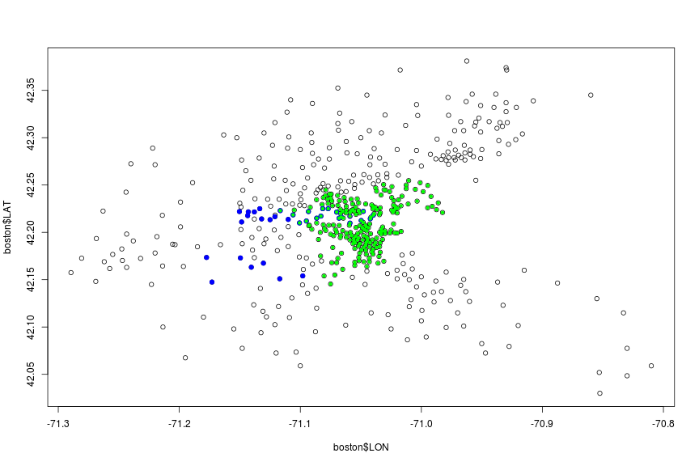

```r
# Plot observations
plot(boston$LON, boston$LAT)

# Tracts alongside the Charles River
points(boston$LON[boston$CHAS == 1], boston$LAT[boston$CHAS == 1], col = "blue",
    pch = 19)

# Plot MIT
points(boston$LON[boston$TRACT == 3531], boston$LAT[boston$TRACT == 3531], col = "red",
    pch = 20)

# Plot polution
points(boston$LON[boston$NOX >= 0.55], boston$LAT[boston$NOX >= 0.55], col = "green",
    pch = 20)
```

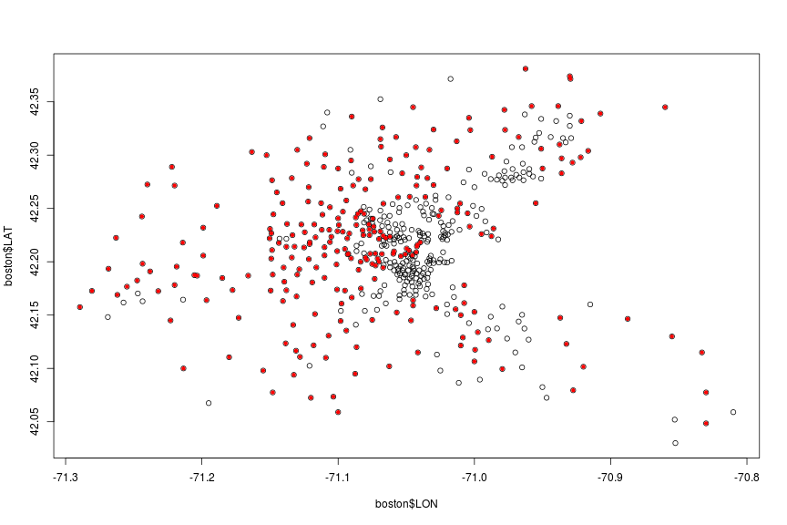

```r
# Plot prices
plot(boston$LON, boston$LAT)
points(boston$LON[boston$MEDV >= 21.2], boston$LAT[boston$MEDV >= 21.2], col = "red",
    pch = 20)
```

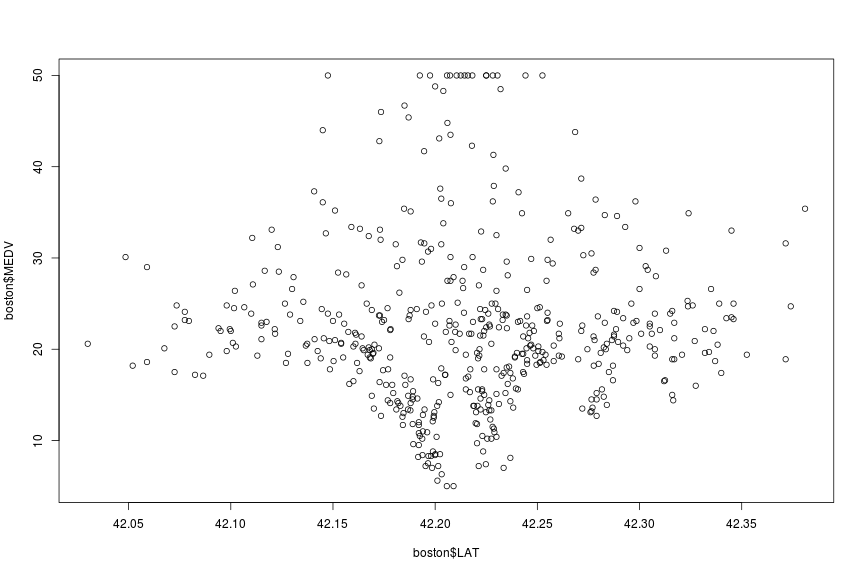

```r
# Plot LAT and LON vs. MEDV
plot(boston$LAT, boston$MEDV)
```

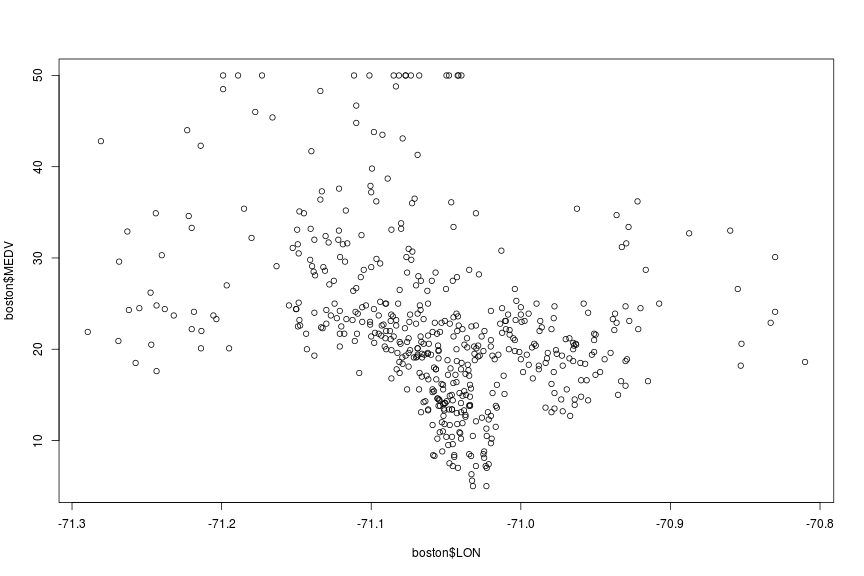

```r
plot(boston$LON, boston$MEDV)
```

# *Regression Model*

```r
latlonlm <- lm(MEDV ~ LAT + LON, data = boston)
summary(latlonlm)
```

```
##
## Call:
## lm(formula = MEDV ~ LAT + LON, data = boston)
##
## Residuals:
##    Min     1Q Median     3Q    Max
## -16.46  -5.59  -1.30   3.69  28.13
##
## Coefficients:
##             Estimate Std. Error t value Pr(>|t|)
## (Intercept) -3178.47     484.94   -6.55  1.4e-10 ***
## LAT             8.05       6.33    1.27      0.2
## LON           -40.27       5.18   -7.77  4.5e-14 ***
## ---
## Signif. codes:  0 '***' 0.001 '**' 0.01 '*' 0.05 '.' 0.1 ' ' 1
##
## Residual standard error: 8.69 on 503 degrees of freedom
## Multiple R-squared: 0.107,   Adjusted R-squared: 0.104
## F-statistic: 30.2 on 2 and 503 DF,  p-value: 4.16e-13
```

```r
# latlonlm$fitted.values
```

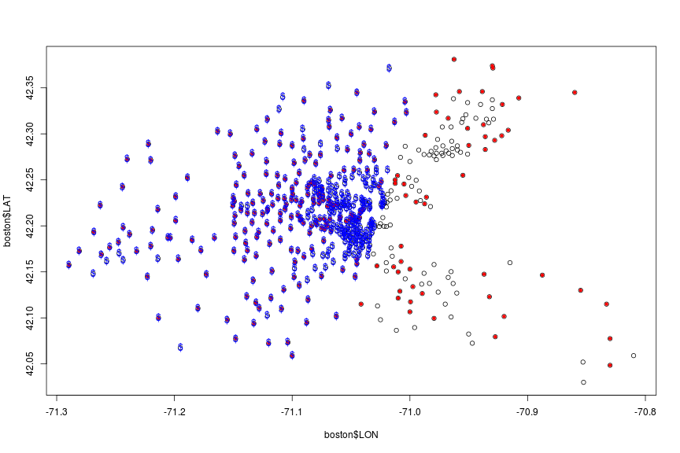

```r
# Visualize regression output
plot(boston$LON, boston$LAT)
points(boston$LON[boston$MEDV >= 21.2], boston$LAT[boston$MEDV >= 21.2], col = "red",
    pch = 20)

points(boston$LON[latlonlm$fitted.values >= 21.2], boston$LAT[latlonlm$fitted.values >=
    21.2], col = "blue", pch = "$")
```

# *Regression Tree*

```r
# Load CART packages
library(rpart)
library(rpart.plot)

# CART model
latlontree = rpart(MEDV ~ LAT + LON, data = boston)
```

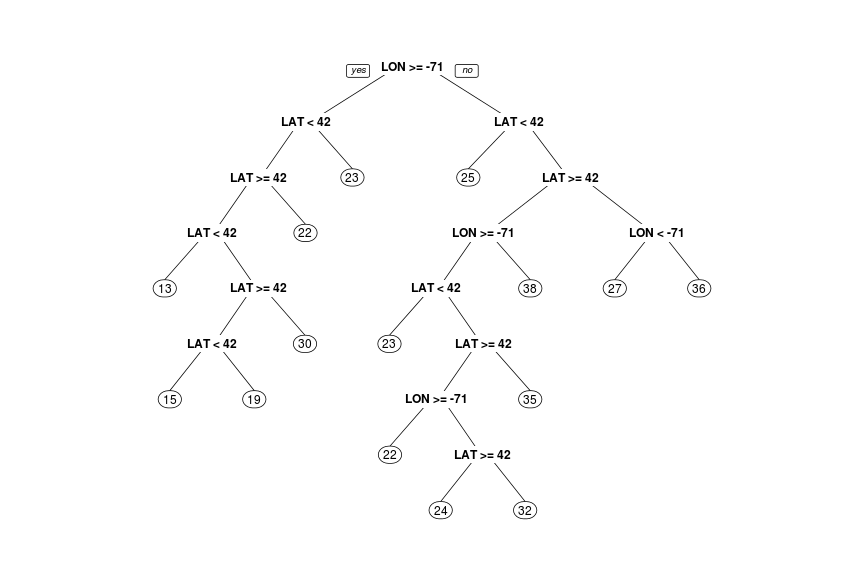

```r
# Tree
prp(latlontree)
```

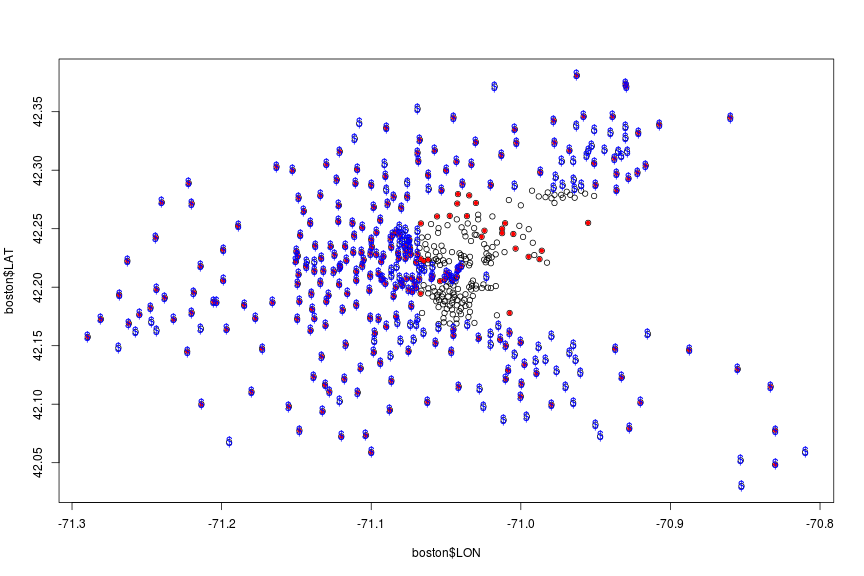

```r
# Visualize output
plot(boston$LON, boston$LAT)
points(boston$LON[boston$MEDV >= 21.2], boston$LAT[boston$MEDV >= 21.2], col = "red",
    pch = 20)

fittedvalues = predict(latlontree)
points(boston$LON[fittedvalues >= 21.2], boston$LAT[fittedvalues >= 21.2], col = "blue",
    pch = "$")
```

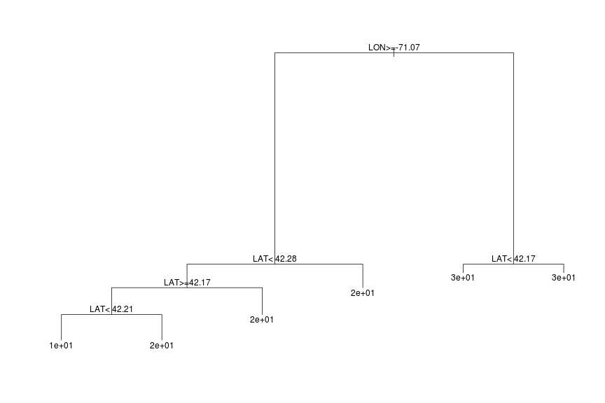

```r
# Simplify tree by increasing minbucket
latlontree = rpart(MEDV ~ LAT + LON, data = boston, minbucket = 50)
plot(latlontree)
text(latlontree)
```

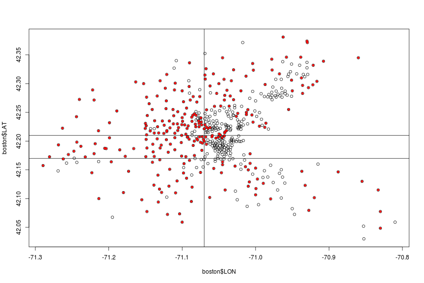

```r
# Visualize Output
plot(boston$LON, boston$LAT)
abline(v = -71.07)
abline(h = 42.21)
abline(h = 42.17)
points(boston$LON[boston$MEDV >= 21.2], boston$LAT[boston$MEDV >= 21.2], col = "red",
    pch = 20)
```

# *Building the Model*

```r
# Let's use all the variables

# Split the data
library(caTools)
set.seed(123)
split = sample.split(boston$MEDV, SplitRatio = 0.7)
train = subset(boston, split == TRUE)
test = subset(boston, split == FALSE)

# Create linear regression
linreg = lm(MEDV ~ LAT + LON + CRIM + ZN + INDUS + CHAS + NOX + RM + AGE + DIS +
    RAD + TAX + PTRATIO, data = train)
summary(linreg)
```

```
##
## Call:
## lm(formula = MEDV ~ LAT + LON + CRIM + ZN + INDUS + CHAS + NOX +
##     RM + AGE + DIS + RAD + TAX + PTRATIO, data = train)
##
## Residuals:
##    Min     1Q Median     3Q    Max
## -14.51  -2.71  -0.68   1.79  36.88
##
## Coefficients:
##              Estimate Std. Error t value Pr(>|t|)
## (Intercept) -2.52e+02   4.37e+02   -0.58    0.564
## LAT          1.54e+00   5.19e+00    0.30    0.766
## LON         -2.99e+00   4.79e+00   -0.62    0.533
## CRIM        -1.81e-01   4.39e-02   -4.12  4.8e-05 ***
## ZN           3.25e-02   1.88e-02    1.73    0.084 .
## INDUS       -4.30e-02   8.47e-02   -0.51    0.612
## CHAS         2.90e+00   1.22e+00    2.38    0.018 *
## NOX         -2.16e+01   5.41e+00   -3.99  8.0e-05 ***
## RM           6.28e+00   4.83e-01   13.02  < 2e-16 ***
## AGE         -4.43e-02   1.79e-02   -2.48    0.014 *
## DIS         -1.58e+00   2.84e-01   -5.55  5.6e-08 ***
## RAD          2.45e-01   9.73e-02    2.52    0.012 *
## TAX         -1.11e-02   5.45e-03   -2.04    0.042 *
## PTRATIO     -9.83e-01   1.94e-01   -5.07  6.4e-07 ***
## ---
## Signif. codes:  0 '***' 0.001 '**' 0.01 '*' 0.05 '.' 0.1 ' ' 1
##
## Residual standard error: 5.6 on 350 degrees of freedom
## Multiple R-squared: 0.665,   Adjusted R-squared: 0.653
## F-statistic: 53.4 on 13 and 350 DF,  p-value: <2e-16
```

```r
# Make predictions
linreg.pred = predict(linreg, newdata = test)
linreg.sse = sum((linreg.pred - test$MEDV)^2)
linreg.sse
```

```
## [1] 3037
```

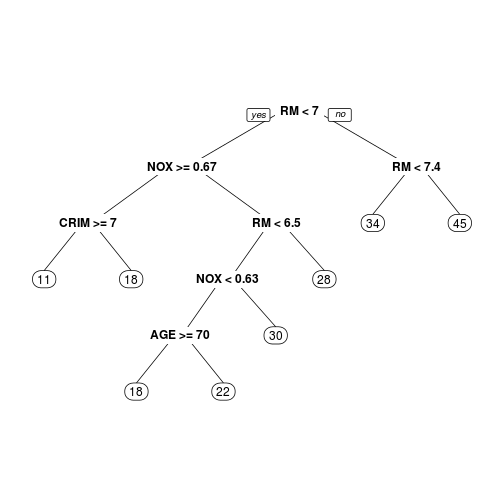

```r
# Create a CART model
tree = rpart(MEDV ~ LAT + LON + CRIM + ZN + INDUS + CHAS + NOX + RM + AGE +
    DIS + RAD + TAX + PTRATIO, data = train)
prp(tree)
```

```r
# Make predictions
tree.pred = predict(tree, newdata = test)
tree.sse = sum((tree.pred - test$MEDV)^2)
tree.sse
```

```
## [1] 4329
```

Thus, regression trees are not as good as linear regression for predicting the average median prices in Boston!

# *Cross Validation*

```r
# Load libraries for cross-validation
library(caret)
library(e1071)
# Number of folds
tr.control = trainControl(method = "cv", number = 10)

# cp values
cp.grid = expand.grid(.cp = (0:10) * 0.001)

# Cross-validation
tr = train(MEDV ~ LAT + LON + CRIM + ZN + INDUS + CHAS + NOX + RM + AGE + DIS +
    RAD + TAX + PTRATIO, data = train, method = "rpart", trControl = tr.control,
    tuneGrid = cp.grid)
tr
```

```
## 364 samples
##  15 predictors
##
## No pre-processing
## Resampling: Cross-Validation (10 fold)
##
## Summary of sample sizes: 326, 327, 328, 328, 328, 328, ...
##
## Resampling results across tuning parameters:
##
##   cp     RMSE  Rsquared  RMSE SD  Rsquared SD
##   0      5     0.8       2        0.1
##   0.001  5     0.8       2        0.1
##   0.002  5     0.7       2        0.1
##   0.003  5     0.7       2        0.2
##   0.004  5     0.7       2        0.2
##   0.005  5     0.7       2        0.2
##   0.006  5     0.7       2        0.2
##   0.007  5     0.7       2        0.2
##   0.008  5     0.7       2        0.2
##   0.009  5     0.7       2        0.2
##   0.01   5     0.7       2        0.2
##
## RMSE was used to select the optimal model using  the smallest value.
## The final value used for the model was cp = 0.001.
```

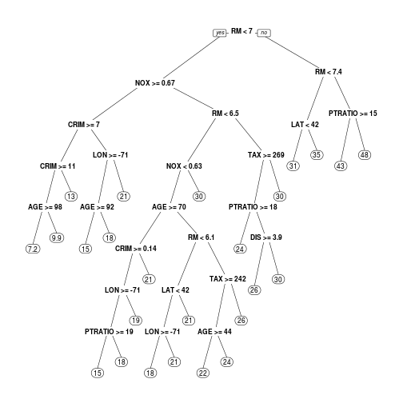

```r
# Extract tree
best.tree = tr$finalModel
prp(best.tree)
```

```r
# Make predictions
best.tree.pred = predict(best.tree, newdata = test)
best.tree.sse = sum((best.tree.pred - test$MEDV)^2)
best.tree.sse
```

```
## [1] 3676
```

Again, linear regression is still a better model than the cross-validation method!